# Hierarchical, coregionalized GPs

Simon Dirmeier <simon.dirmeier @ web.de>

May 2021

In this case study we compare a multi-level Gaussian process model to a hierarchical coregionalized Gaussian process model in terms of their predictive performance and their MCMC sampling diagnostics. The case study is inspired by Rob Trangucci’s talk at StanCon 2017 (Trangucci 2017), where he demonstrated a multi-level GP model to predict US presidential votes.

Usually I implement my notebooks in Stan, but since I wanted to test [Numpyro](http://num.pyro.ai/en/latest/index.html) for a long time, we will be using it here for a change. Feedback and comments are welcome!

```python
import warnings
import numpy as onp
import pandas as pd

import jax
from jax import vmap
import jax.numpy as np
import jax.random as random

import numpyro
import numpyro.distributions as nd
from numpyro.infer import MCMC, NUTS

import matplotlib.pyplot as plt
import seaborn as sns
import arviz as az

import palettes

palettes.set_theme()
warnings.filterwarnings('ignore')
```

# Presidential elections

The data set consists of counts of votes for US parties between 1976 and 2016 adopted from the [data of Rob’s talk](https://github.com/stan-dev/stancon_talks/tree/master/2017/Contributed-Talks/08_trangucci/data_pres_forecast). The counts are available for every state in the US. We can either model these counts directly, or, following Trangucci (2017), we model the proportion of votes one party received in a state.

```python
D = pd.read_csv("./data/elections.csv")
D.loc[:, "proportion"] = D.dem / (D.dem + D.rep)
D
```

```
     year    dem     rep         region state  proportion
0    1976  44058   71555  Mountain West    AK    0.381082
1    1980  41842   86112  Mountain West    AK    0.327008
2    1984  62007  138377  Mountain West    AK    0.309441
3    1988  72584  119251  Mountain West    AK    0.378367
4    1992  78294  102000  Mountain West    AK    0.434257
..    ...    ...     ...            ...   ...         ...
545  2000  60481  147947  Mountain West    WY    0.290177
546  2004  70776  167629  Mountain West    WY    0.296873
547  2008  82868  164958  Mountain West    WY    0.334380
548  2012  69286  170962  Mountain West    WY    0.288394
549  2016  55973  174419  Mountain West    WY    0.242947

[550 rows x 6 columns]
```

The geographical location of the states suggest a grouping per region. Below we plot the proportion of votes for the democratic party for every state and region for the period between 1976 and 2016.

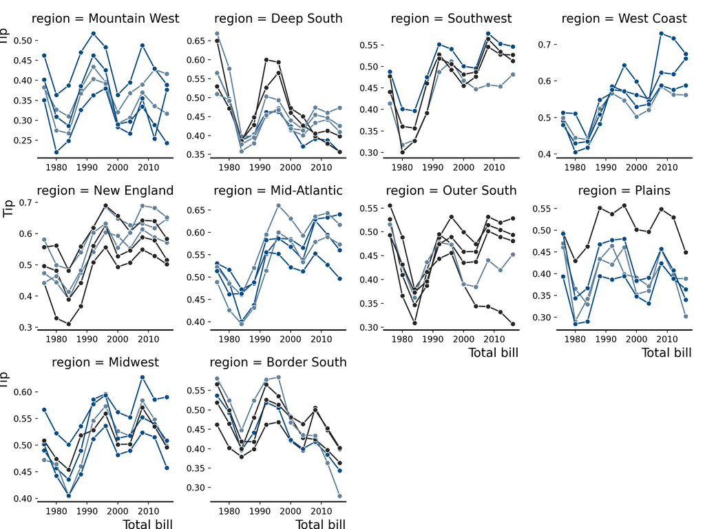

```python
g = sns.FacetGrid(
    D,
    col="region",
    hue="state",
    palette=palettes.discrete_sequential_colors(),
    col_wrap=4,
    sharex=False,
    sharey=False
)
_ = g.map_dataframe(
    sns.lineplot, x="year", y="proportion", style="state", markers="o"
)
_ = g.set_axis_labels("Total bill", "Tip")
sns.despine(left=True)
plt.show()
```

The data suggests a model that considers a general national trend per election year and region, and a baseline offset for democratic votes. Within regions there is also a clear correlation between states that suggests either coregionalisation or a hierarchical prior.

# Preprocessing

Before we model the data, we implement some utility functions. We use a exponentiated quadratic covariance function throughout the case study, which in Jax can be implemented like this.

```python
def rbf(X1, X2, sigma=1.0, rho=1.0, jitter=1.0e-6):
    X1_e = np.expand_dims(X1, 1) / rho
    X2_e = np.expand_dims(X2, 0) / rho
    d = np.sum((X1_e - X2_e) ** 2, axis=2)
    K = sigma * np.exp(-0.5 * d) + np.eye(d.shape[0]) * jitter
    return K
```

To measure the sampling time our models take, we also implement a decorator that wraps a function and times it.

```python
def timer(func):
    from timeit import default_timer
    def f(*args, **kwargs):
        start = default_timer()
        res = func(*args, **kwargs)
        stop = default_timer()
        print(f"Elapsed time: {stop - start}")
        return res
    return f
```

For inference, we use Numpyro’s NUTS and add our previously defined decorator to it:

```python
@timer
def sample(model, niter=1000):
    rng_key, rng_key_predict = random.split(random.PRNGKey(23))

    kernel = NUTS(model)
    mcmc = MCMC(
        kernel,
        num_warmup=niter,
        num_samples=niter,
        num_chains=4,
        progress_bar=False,
    )
    mcmc.run(
        rng_key,
        y,
        Xu,
        n_times,
        time_idxs,
        n_states,
        state_idxs,
        n_regions,
        region_idxs,
        train_idxs,
        n_states_per_region,
    )
    return mcmc
```

Finally, we make a prediction by sampling from the joint posterior.

```python
def predict(mcmc, n=5):
    samples = mcmc.get_samples()
    rng_key, rng_key_predict = random.split(random.PRNGKey(0))
    vmap_args = (
        random.split(rng_key_predict, samples["nu"].shape[0]),
        samples["nu"],
        samples["eta"],
    )
    preds_map = jax.vmap(
        lambda key, nu, eta: np.mean(
            nd.Beta(eta, nu - eta).sample(key, sample_shape=(n,)), axis=0
        )
    )
    preds = preds_map(*vmap_args)
    means = np.mean(preds, axis=0)
    quantiles = np.percentile(preds, [5.0, 95.0], axis=0)
    return means, quantiles
```

We implement both models by regressing the proportions on the electoral year. For that we convert the years to numerical values first and then sort the data frame by region, state and year.

```python
years = pd.to_datetime(D.year)
years = (years - years.min()) / pd.Timedelta(1)

D.loc[:, ("year_numerical")] = years
D.loc[:, ("region_idxs")] = D["region"].apply(
    lambda x: list(D.region.unique()).index(x)
)
D.loc[:, ("state_idxs")] = D["state"].apply(
    lambda x: list(D.state.unique()).index(x)
)
D.loc[:, ("time_idxs")] = D["year_numerical"].apply(
    lambda x: list(D.year_numerical.unique()).index(x)
)
D = D.sort_values(["region", "state", "year_numerical"])
D
```

```
     year      dem      rep  ... region_idxs state_idxs  time_idxs
154  1976  1014714  1183958  ...           9         14          0
155  1980   844197  1255656  ...           9         14          1
156  1984   841481  1377230  ...           9         14          2
157  1988   860643  1297763  ...           9         14          3
158  1992   848420   989375  ...           9         14          4
..    ...      ...      ...  ...         ...        ...        ...
512  2000  1247652  1108864  ...           3         46          6
513  2004  1510201  1304894  ...           3         46          7
514  2008  1750848  1229216  ...           3         46          8
515  2012  1755396  1290670  ...           3         46          9
516  2016  1742718  1221747  ...           3         46         10

[550 rows x 10 columns]
```

```python
X = np.array(D["year_numerical"].values).reshape(-1, 1)
Xu = np.unique(X).reshape(-1, 1)
y = np.array(D["proportion"].values)
```

In addition, we need to compute the indexes of the time points, states and regions, such that we can correctly assign everything.

```python
time_idxs = np.array(D["time_idxs"].values)
n_times = len(np.unique(time_idxs))
state_idxs = np.array(D["state_idxs"].values)
n_states = len(np.unique(state_idxs))
region_idxs = np.array(D["region_idxs"].values)
n_regions = len(np.unique(region_idxs))

n_states_per_region = np.array(
    D.groupby(["region", "state"]).size().groupby("region").size()
)
```

Since we also want to compare predictive performance, we treat one of 11 data points as test point and the other 10 as train indexes. That means for a data set of 550 observations (50 * 11 states), we use 50 test points.

```python
train_idxs = np.tile(np.arange(11) != 7, n_states)
```

# Likelihood

To model the data, we will need to choose a suitable likelihood. A fitting one having the same support as our data $Y$ is the Beta distribution:

$$P(y \mid \alpha, \beta) = \frac{1}{B(\alpha, \beta)} y^{\alpha - 1} (1 - y)^{\beta - 1}$$
For regression modelling, this one is a bit awkward to use, so we use its alternative parameterization following the [Stan manual](https://mc-stan.org/docs/2_26/functions-reference/beta-proportion-distribution.html):

$$P(y \mid \mu, \kappa) = \frac{1}{B\left(\mu\kappa, (1 - \mu)\kappa\right)} y^{\mu\kappa -1} (1 - y)^{(1 - \mu)\kappa -1}$$
Unfortunately, Numpyro does not have this parameterization, but this is not a problem as we can easily reparameterize.

# Prediction

For Gaussian likelihoods and given a posterior sample of the parameters of the covariance function, prediction boils down to Gaussian conditioning. For non-Gaussian likelihoods, we would first infer the posterior of the latent GP $P(f \mid y, X)$ and given this compute the posterior predictive

$$P(y^* \mid y, X, X^*) = \int \int P(y^* \mid f^*) P(f^* \mid f, X, X^*) P)(f \mid y, X) df df^*$$
We can directly model this via the joint distribution of the observed (training data) and unobserved (testing data) responses, i.e.,

$$P(y, y^* \mid X, X^*)$$
Specifically, we the generative model is defined on the entire set of predictors $X, X*$, but the likelihood only considers observed values $y$.

# A multi-level GP

Our first model will be an adoption of Rob’s model, with the exception that we will use GPs entirely. The generative model reads:

$$\begin{aligned}
y_{rst} &\sim \text{Beta}\left(\eta_{rst}, \nu - \eta_{rst} \right) \\
\eta_{rst} & = \nu * \text{logit}^{-1}\left(\mu + f_{rt} + g_{st} + h_{st} \right) \\
f_r & \sim GP(0, K(\sigma^f, \rho^f)) \\
g_{s} & \sim GP(0, K(\sigma^g, \rho^g )) \\
h_{s} & \sim GP(0, K(\sigma^h, \rho^h_{s})) \\
\nu & \sim \text{Gamma}(5, 0.01) \\
\mu & \sim \text{Normal}(0, 0.5)
\end{aligned}$$
The other parameters (covariance variances and lengthscales) are drawn from distributions with appropriate support. Notably, we are using a sum of three GPs per state: a regional GP with common variance and lengthscale between all regions, a state-level GP with common variance and length-scale between all states, and another state-level GP with common variance between states, but individual lengthscales for every state to account for everything that is not explained by the other two. The function below implements the generative model above:

```python
def multilevel_model(
    y,
    Xu,
    n_times,
    time_idxs,
    n_states,
    state_idxs,
    n_regions,
    region_idxs,
    train_idxs,
    n_states_per_region,
):
    n = 3
    sigma_tot = numpyro.sample("sigma_tot", nd.Gamma(3.0, 3.0))
    sigma_prop = numpyro.sample("sigma_prop", nd.Dirichlet(np.repeat(2.0, n)))
    sigmas = n * sigma_prop * sigma_tot

    rho_region_gp = numpyro.sample("rho_region_gp", nd.LogNormal(0.0, 1.0))
    K_region_gp = rbf(Xu, Xu, sigmas[0], rho_region_gp)
    L_region_gp = np.linalg.cholesky(K_region_gp)
    with numpyro.plate("regions", size=n_regions):
        f_reg_tilde = numpyro.sample(
            "f_reg_tilde", nd.Normal(loc=np.zeros((Xu.shape[0], 1)))
        )
        f_reg = numpyro.deterministic("f_reg", L_region_gp @ f_reg_tilde)
    f_reg = np.repeat(f_reg, n_states_per_region, axis=1)
    f_reg = f_reg.T.reshape(-1)

    rho_state_gp = numpyro.sample("rho_state_gp", nd.LogNormal(0.0, 1.0))
    K_state_gp = rbf(Xu, Xu, sigmas[1], rho_state_gp)
    L_state_gp = np.linalg.cholesky(K_state_gp)
    with numpyro.plate("states", size=n_states):
        f_stat_tilde = numpyro.sample(
            "f_stat_tilde", nd.Normal(loc=np.zeros((Xu.shape[0], 1)))
        )
        f_stat = numpyro.deterministic("f_stat", L_state_gp @ f_stat_tilde)
    f_stat = f_stat.reshape(-1)

    with numpyro.plate("states", size=n_states):
        rho = numpyro.sample("rho", nd.LogNormal(0.0, 1.0))
        K = rbf(Xu, Xu, sigmas[2], rho)
        L = np.linalg.cholesky(K)
        f_tilde = numpyro.sample(
            "f_tilde", nd.Normal(loc=np.zeros((Xu.shape[0], 1)))
        )
        f = numpyro.deterministic("f", L @ f_tilde)
    f = f.reshape(-1)

    nu = numpyro.sample("nu", nd.Gamma(5.0, 0.01))
    mu = numpyro.sample("mu", nd.Normal(0.0, 0.5))
    eta = numpyro.deterministic(
        "eta", nu * jax.scipy.special.expit(mu + f_reg + f_stat + f)
    )
    numpyro.sample(
        "y", nd.Beta(eta[train_idxs], nu - eta[train_idxs]), obs=y[train_idxs]
    )
```

Having defined the model, posterior inference is fairly easy. We also compute MCMC diagnostics to check if the posteriors mix, no divergences occur, etc.

```python
mcmc_multilevel = sample(multilevel_model)
```

```
Elapsed time: 199.51950429099998
```

```python
rhat_multilevel = az.rhat(mcmc_multilevel)
ess_multilevel = az.ess(mcmc_multilevel)
```

```python
rhat_multilevel.data_vars
```

```
Data variables: (12/14)
    eta            (eta_dim_0) float64 1.053 1.053 1.053 ... 1.054 1.054 1.054
    f              (f_dim_0, f_dim_1) float64 1.009 1.012 1.003 ... 1.006 1.002
    f_reg          (f_reg_dim_0, f_reg_dim_1) float64 1.001 1.0 ... 1.001 1.001
    f_reg_tilde    (f_reg_tilde_dim_0, f_reg_tilde_dim_1) float64 1.001 ... 1.0
    f_stat         (f_stat_dim_0, f_stat_dim_1) float64 1.008 1.016 ... 1.003
    f_stat_tilde   (f_stat_tilde_dim_0, f_stat_tilde_dim_1) float64 1.004 ......
    ...             ...
    nu             float64 1.054
    rho            (rho_dim_0) float64 0.9998 0.9998 1.0 ... 1.0 1.001 1.001
    rho_region_gp  float64 1.002
    rho_state_gp   float64 1.004
    sigma_prop     (sigma_prop_dim_0) float64 1.008 1.052 1.039
    sigma_tot      float64 1.004
```

```python
ess_multilevel.data_vars
```

```
Data variables: (12/14)
    eta            (eta_dim_0) float64 75.37 75.63 75.35 ... 74.75 74.73 74.6
    f              (f_dim_0, f_dim_1) float64 531.1 408.5 ... 812.8 4.051e+03
    f_reg          (f_reg_dim_0, f_reg_dim_1) float64 2.77e+03 ... 3.26e+03
    f_reg_tilde    (f_reg_tilde_dim_0, f_reg_tilde_dim_1) float64 2.77e+03 .....
    f_stat         (f_stat_dim_0, f_stat_dim_1) float64 620.7 ... 4.531e+03
    f_stat_tilde   (f_stat_tilde_dim_0, f_stat_tilde_dim_1) float64 2.344e+03...
    ...             ...
    nu             float64 74.02
    rho            (rho_dim_0) float64 8.034e+03 7.163e+03 ... 8.305e+03
    rho_region_gp  float64 1.267e+03
    rho_state_gp   float64 2.108e+03
    sigma_prop     (sigma_prop_dim_0) float64 353.6 111.4 130.5
    sigma_tot      float64 809.0
```

Both of the diagnostics are ok. The R-hats should be ideally around one, while the effective sample sizes should be as high as possible.

Next we make sample from the posterior predictive, compute its mean and quantiles.

```python
means_multilevel, quantiles_multilevel = predict(mcmc_multilevel)

Dm = D.copy()
Dm.loc[:, "y_hat"] = onp.array(means_multilevel)
Dm.loc[:, "y_hat_lower"] = onp.array(quantiles_multilevel[0])
Dm.loc[:, "y_hat_upper"] = onp.array(quantiles_multilevel[1])
```

Let’s overlay the mean of the posterior predictive to the actual data.

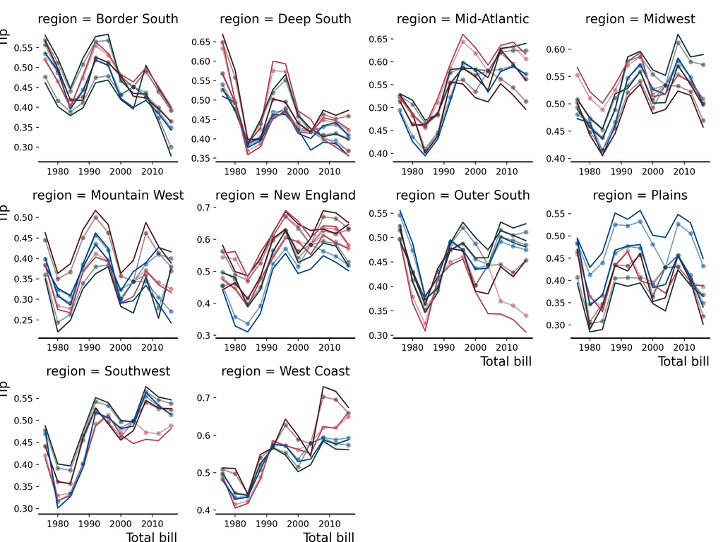

```python
g = sns.FacetGrid(
    Dm,
    col="region",
    hue="state",
    col_wrap=4,
    palette=palettes.discrete_diverging_colors(),
    sharex=False,
    sharey=False
)
_ = g.map_dataframe(
    sns.lineplot,
    x="year",
    y="y_hat",
    style="state",
    marker="o",
    alpha=0.5
)
_ = g.map_dataframe(
    sns.lineplot,
    x="year",
    y="proportion",
    style="state",
)
_ = g.set_axis_labels("Total bill", "Tip")
sns.despine(left=True)
plt.show()
```

The predictions also look good. Let’s in the end compute the average absolute error of the test indexes before we turn to fitting the second model:

```python
np.mean(np.abs(Dm.proportion[~train_idxs].values - Dm.y_hat[~train_idxs].values))
```

```
DeviceArray(0.036768, dtype=float32)
```

# A coregionalized GP

In the model above, we used two GPs for a state, one where the lengthscale of the covariance function is shared among states and one where it is allowed to vary for every state. We can alternatively try to explicitely correlate the state-level GPs using a coregion covariance function. The generative model has the following form:

$$\begin{aligned}
y_{rst} &\sim \text{Beta}\left(\eta_{rst}, \nu - \eta_{rst} \right) \\
\eta_{rst} & = \nu * \text{logit}^{-1}\left(\mu + f_{rt} + h_{r[s]t} \right) \\
f_r & \sim GP \left(0, K(\sigma^f, \rho^f)\right) \\
h_{r} & \sim GP\left(0, K(\sigma^h_{r}, \rho^h_{r}), C(\omega_r)\right) \\
\nu & \sim \text{Gamma}(5, 0.01) \\
\mu & \sim \text{Normal}(0, 0.5)
\end{aligned}$$

Here, the sampling statement $h_{r} \sim GP\left(0, K(\sigma^h_{r}, \rho^h_{r}), C(\omega_r)\right)$ represents a “Matrix” GP, i.e., a stochastic process of which any finite sample is a matrix normal random variable with a *fixed* number of columns. In this case the number of columns is the cardinality of $\{i : i \in r\}$. Or: supposing region $r$ consists of six states, then a sampling from $h_r$ yields always a matrix with six columns.

But how do we sample from it? Fortunately we can reparameterize the sampling statement. We first sample a $T \times q$ matrix of standard normals, where $T$ is the number of timepoints and $q$ is the cardinality of $\{i : i \in r\}$, then left multiply it with the square of the covariance matrix $ K(1, ^{h}_{r})$ (its Cholesky decomposition) while setting the covariance function’s variance parameter to $1.0$ (since the variance is not identified) and then right multiply the product with the root of the covariance $C(\omega)$. We can implement the model like this:

```python
def coregional_model(
    y,
    Xu,
    n_times,
    time_idxs,
    n_states,
    state_idxs,
    n_regions,
    region_idxs,
    train_idxs,
    n_states_per_region,
):
    rho_region_gp = numpyro.sample("rho_region_gp", nd.LogNormal(0.0, 1.0))
    sigma_region_gp = numpyro.sample("sigma_region_gp", nd.LogNormal(0.0, 1.0))
    K_region_gp = rbf(Xu, Xu, sigma_region_gp, rho_region_gp)
    L_region_gp = np.linalg.cholesky(K_region_gp)
    with numpyro.plate("regions", size=n_regions):
        f_reg_tilde = numpyro.sample(
            "f_reg_tilde", nd.Normal(loc=np.zeros((Xu.shape[0], 1)))
        )
        f_reg = numpyro.deterministic("f_reg", L_region_gp @ f_reg_tilde)
    f_reg = np.repeat(f_reg, n_states_per_region, axis=1)
    f_reg = f_reg.T.reshape(-1)

    fs = []
    for i, q in enumerate(n_states_per_region):
        rho = numpyro.sample(f"rho_{i}", nd.LogNormal(0.0, 1.0))
        K = rbf(Xu, Xu, 1.0, rho)
        L = np.linalg.cholesky(K)
        sigma = numpyro.sample(f"sigma_{i}", nd.LogNormal(np.zeros(q), 1.0))
        omega = numpyro.sample(f"omega_{str(i)}", nd.LKJCholesky(q, 2.0))
        f_tilde = numpyro.sample(
            f"f_tilde_{i}", nd.Normal(loc=np.zeros((Xu.shape[0], q)))
        )
        f = numpyro.deterministic(
            f"f_{i}", L @ f_tilde @ (np.diag(np.sqrt(sigma)) @ omega).T
        )
        fs.append(f.reshape(-1))
    f = np.concatenate(fs)

    nu = numpyro.sample("nu", nd.Gamma(5.0, 0.01))
    mu = numpyro.sample("mu", nd.Normal(0.0, 0.5))
    eta = numpyro.deterministic(
        "eta", nu * jax.scipy.special.expit(mu + f_reg + f)
    )
    numpyro.sample(
        "y", nd.Beta(eta[train_idxs], nu - eta[train_idxs]), obs=y[train_idxs]
    )
```

As above, after sampling we compute MCMC diagnostics.

```python
mcmc_coregional = sample(coregional_model)
```

```
Elapsed time: 666.5036768950013
```

```python
rhat_coregional = az.rhat(mcmc_coregional)
ess_coregional = az.ess(mcmc_coregional)
```

```python
rhat_coregional.data_vars
```

```
Data variables: (12/57)
    eta              (eta_dim_0) float64 1.562 1.556 1.563 ... 1.589 1.585 1.58
    f_0              (f_0_dim_0, f_0_dim_1) float64 1.007 1.023 ... 1.06 1.195
    f_1              (f_1_dim_0, f_1_dim_1) float64 1.004 1.004 ... 1.018 1.034
    f_2              (f_2_dim_0, f_2_dim_1) float64 1.002 1.015 ... 1.089 1.045
    f_3              (f_3_dim_0, f_3_dim_1) float64 1.001 1.002 1.0 ... 1.0 1.0
    f_4              (f_4_dim_0, f_4_dim_1) float64 1.006 1.008 ... 1.002 1.004
    ...               ...
    sigma_5          (sigma_5_dim_0) float64 1.001 1.001 1.01 1.003 1.01 1.013
    sigma_6          (sigma_6_dim_0) float64 1.138 1.112 1.101 1.15 1.161
    sigma_7          (sigma_7_dim_0) float64 1.014 1.054 1.012 1.056 1.011
    sigma_8          (sigma_8_dim_0) float64 1.0 1.004 1.001 1.003
    sigma_9          (sigma_9_dim_0) float64 1.004 1.014 1.013 1.009
    sigma_region_gp  float64 1.009
```

```python
ess_coregional.data_vars
```

```
Data variables: (12/57)
    eta              (eta_dim_0) float64 6.941 6.986 6.958 ... 6.802 6.808 6.842
    f_0              (f_0_dim_0, f_0_dim_1) float64 1.354e+03 201.2 ... 14.25
    f_1              (f_1_dim_0, f_1_dim_1) float64 1.747e+03 ... 101.4
    f_2              (f_2_dim_0, f_2_dim_1) float64 1.9e+03 1.134e+03 ... 58.65
    f_3              (f_3_dim_0, f_3_dim_1) float64 1.214e+03 ... 1.338e+03
    f_4              (f_4_dim_0, f_4_dim_1) float64 1.191e+03 ... 2.194e+03
    ...               ...
    sigma_5          (sigma_5_dim_0) float64 2.087e+03 2.324e+03 ... 1.274e+03
    sigma_6          (sigma_6_dim_0) float64 18.66 23.0 24.98 17.59 16.58
    sigma_7          (sigma_7_dim_0) float64 579.6 51.71 ... 53.16 1.416e+03
    sigma_8          (sigma_8_dim_0) float64 3.407e+03 2.308e+03 ... 2.751e+03
    sigma_9          (sigma_9_dim_0) float64 1.542e+03 459.3 1.098e+03 1.236e+03
    sigma_region_gp  float64 1.016e+03
```

```python
means_coregional, quantiles_coregional = predict(mcmc_coregional)

Dc = D.copy()
Dc.loc[:, "y_hat"] = onp.array(means_coregional)
Dc.loc[:, "y_hat_lower"] = onp.array(quantiles_coregional[0])
Dc.loc[:, "y_hat_upper"] = onp.array(quantiles_coregional[1])
```

We also visualize the predictions again, overlayed over the actual data.

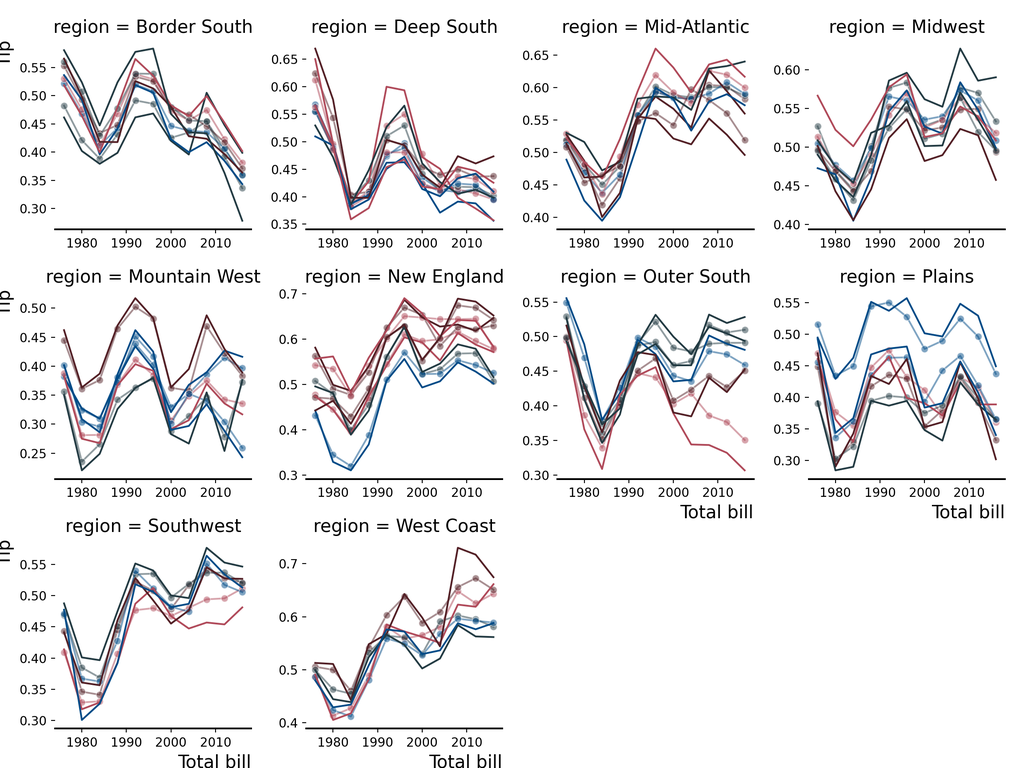

```python
g = sns.FacetGrid(
    Dc,
    col="region",
    hue="state",
    col_wrap=4,
    palette=palettes.discrete_diverging_colors(),
    sharex=False,
    sharey=False
)
_ = g.map_dataframe(
    sns.lineplot,
    x="year",
    y="y_hat",
    style="state",
    marker="o",
    alpha=0.5
)
_ = g.map_dataframe(
    sns.lineplot,
    x="year",
    y="proportion",
    style="state",
)
_ = g.set_axis_labels("Total bill", "Tip")
sns.despine(left=True)
plt.show()
```

As before, the predictions look great, and are hardly different to the other model. Hence, lets’ have a look at the average absolute error of the test data:

```python
np.mean(np.abs(Dc.proportion[~train_idxs].values - Dc.y_hat[~train_idxs].values))
```

```
DeviceArray(0.0300479, dtype=float32)
```

The prediction is a bit better, but the runtime is significantly worse (probably due to the increased dimensionality of the variance paramaters). Hence Rob’s model seems to be the clear winner if we factor in both aspects.

# License

The notebook is licensed under a [Creative Commons Attribution-NonCommercial 4.0 International License](http://creativecommons.org/licenses/by-nc/4.0/).

# References

Trangucci, Rob. 2017. “Hierarchical Gaussian Processes in Stan.” *StanCon*. https://mc-stan.org/events/stancon. https://mc-stan.org/events/stancon2017-notebooks/stancon2017-trangucci-hierarchical-gps.pdf.